# Lecture 301

2020-09-09

## Data visualisation

## Recap

**Prev**: Reproducibility

- 221 Reproducibility
- 222 R and Markdown
- 223 Git
- 224 Practical session

**Now**: Data visualisation

- Grammar of graphics
- ggplot2

## Visual variables

A **visual variable** is an aspect of a **mark** that can be controlled to change its appearance.

Visual variables include:

- Size
- Shape
- Orientation
- Colour (hue)
- Colour value (brightness)
- Texture
- Position (2 dimensions)

## Grammar of graphics

Grammars provide rules for languages

*“The grammar of graphics takes us beyond a limited set of charts (words) to an almost unlimited world of graphical forms (statements)”* (Wilkinson, 2005)

Statistical graphic specifications are expressed in six statements:

1. **Data** manipulation
2. **Variable** transformations (e.g., rank),
3. **Scale** transformations (e.g., log),
4. **Coordinate system** transformations (e.g., polar),
5. **Element**: mark (e.g., points) and visual variables (e.g., color)
6. **Guides** (axes, legends, etc.).

## ggplot2

The `ggplot2` library offers a series of functions for creating graphics **declaratively**, based on the Grammar of Graphics.

To create a graph in `ggplot2`:

- provide the data
- specify elements
  - which visual variables (`aes`)
  - which marks (e.g., `geom_point`)
- apply transformations
- guides

```r
library(tidyverse)
library(nycflights13)
library(knitr)
```

## Histograms

- `x` variable to plot
- `geom_histogram`

```r
nycflights13::flights %>%
  filter(month == 11) %>%
  ggplot(
    aes(
      x = dep_delay
    )
  ) +
  geom_histogram(
    binwidth = 10
  )
```

## Histograms

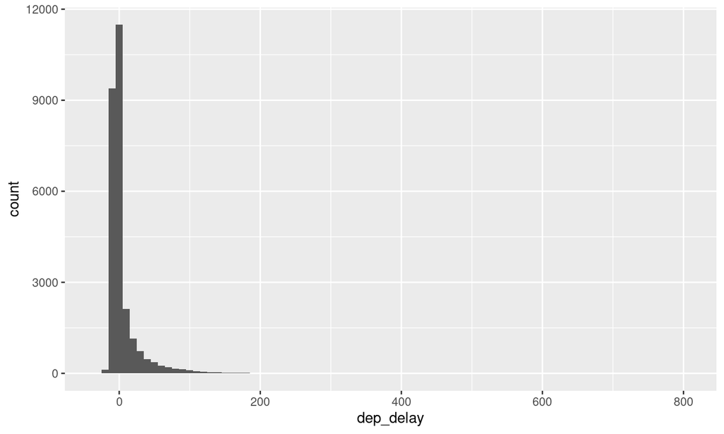

## Boxplots

- `x` categorical variable
- `y` variable to plot
- `geom_boxplot`

```r
nycflights13::flights %>%
  filter(month == 11) %>%
  ggplot(
    aes(
      x = carrier,
      y = arr_delay
    )
  ) +
  geom_boxplot()
```

## Boxplots

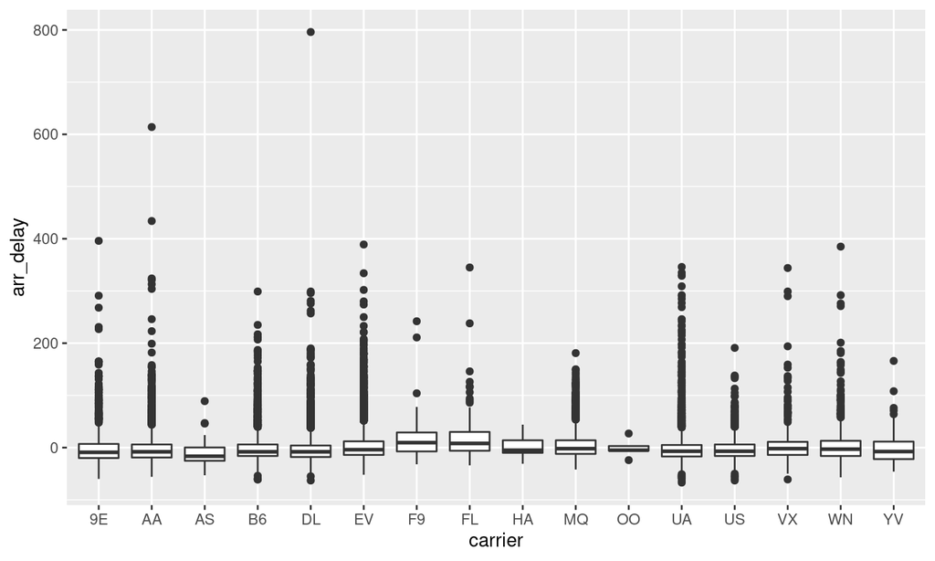

## Jittered points

- `x` categorical variable
- `y` variable to plot
- `geom_jitter`

```r
nycflights13::flights %>%
  filter(month == 11) %>%
  ggplot(
    aes(
      x = carrier,
      y = arr_delay
    )
  ) +
  geom_jitter()
```

## Jittered points

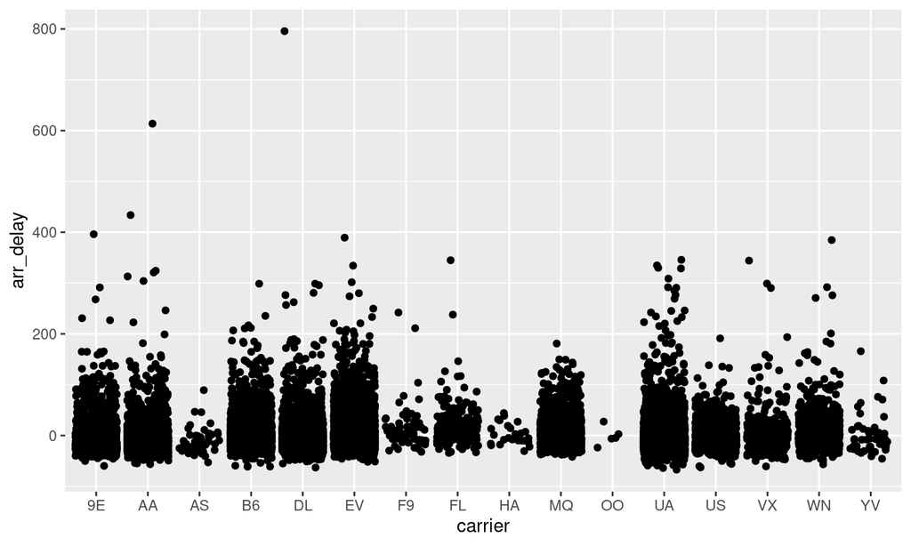

## Violin plot

- `x` categorical variable
- `y` variable to plot
- `geom_violin`

```r
nycflights13::flights %>%
  filter(month == 11) %>%
  ggplot(
    aes(
      x = carrier,
      y = arr_delay
    )
  ) +
  geom_violin()
```

## Violin plot

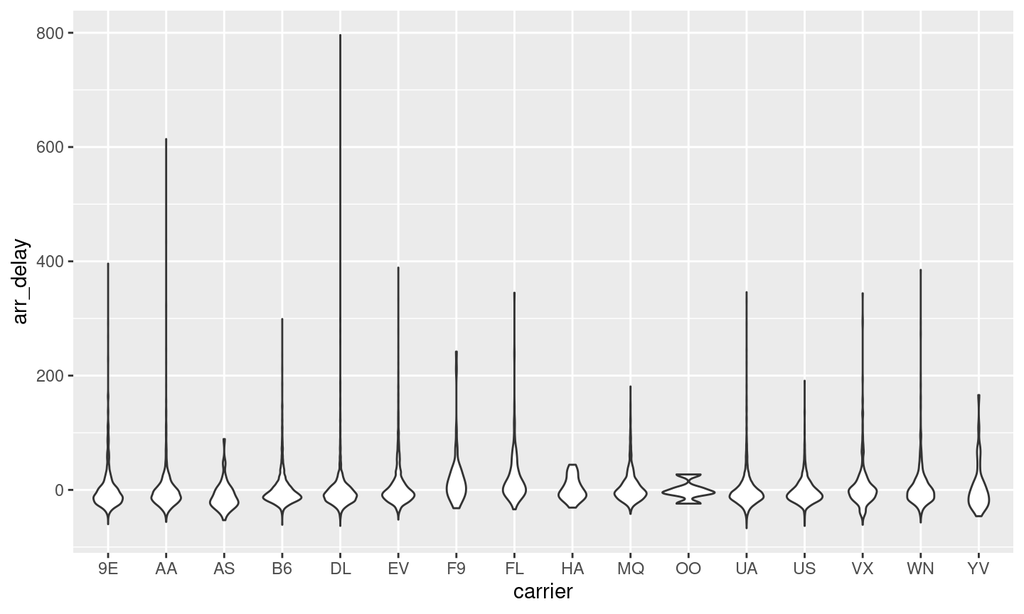

## Lines

- `x` e.g., a temporal variable
- `y` variable to plot
- `geom_line`

```r
nycflights13::flights %>%
  filter(!is.na(dep_delay)) %>%
  mutate(flight_date = ISOdate(year, month, day)) %>%
  group_by(flight_date) %>%
  summarize(avg_dep_delay = mean(dep_delay)) %>%
  ggplot(aes(
    x = flight_date,
    y = avg_dep_delay
  )) +
  geom_line()
```

## Lines

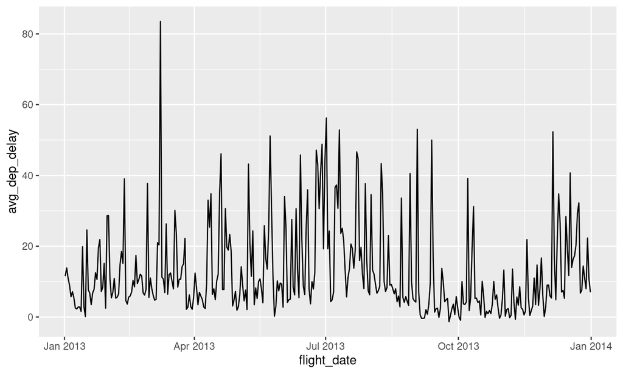

## Scatterplots

- `x` and `y` variable to plot
- `geom_point`

```r
nycflights13::flights %>%
  filter(
    month == 11,
    carrier == "US",
    !is.na(dep_delay),
    !is.na(arr_delay)
  ) %>%
  ggplot(aes(
    x = dep_delay,
    y = arr_delay
  )) +
  geom_point()
```

## Scatterplots

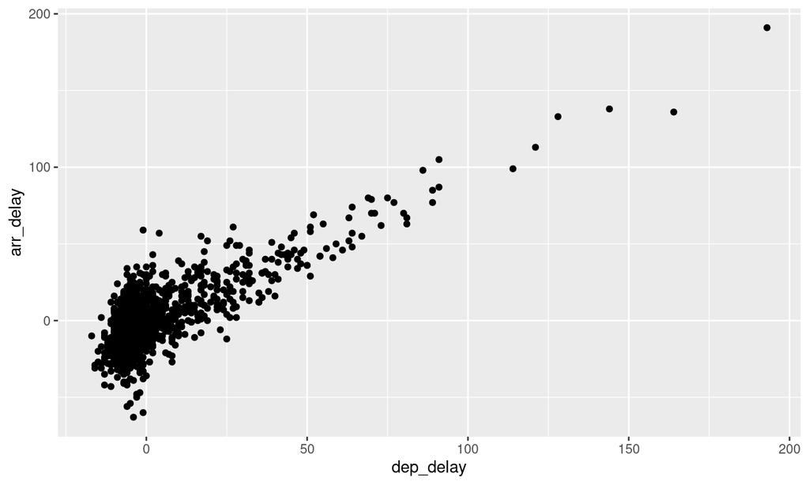

## Overlapping points

- `x` and `y` variable to plot
- `geom_count` counts overlapping points and maps the count to size

```r
nycflights13::flights %>%
  filter(
    month == 11, carrier == "US",
    !is.na(dep_delay), !is.na(arr_delay)
  ) %>%
  ggplot(aes(
    x = dep_delay,
    y = arr_delay
  )) +
  geom_count()
```

## Overlapping points

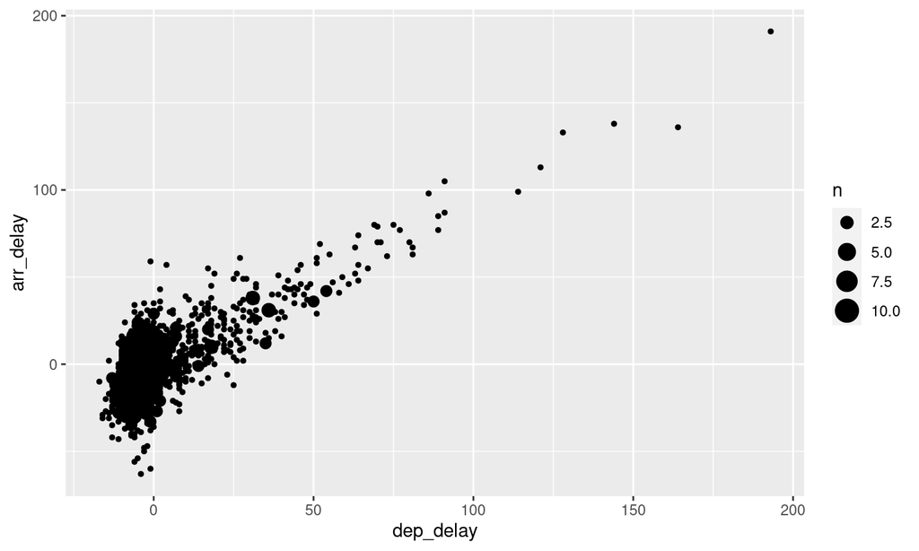

## Bin counts

- `x` and `y` variable to plot
- `geom_bin2d`

```r
nycflights13::flights %>%
  filter(
    month == 11,
    carrier == "US",
    !is.na(dep_delay),
    !is.na(arr_delay)
  ) %>%
  ggplot(aes(
    x = dep_delay,
    y = arr_delay
  )) +
  geom_bin2d()
```

## Bin counts

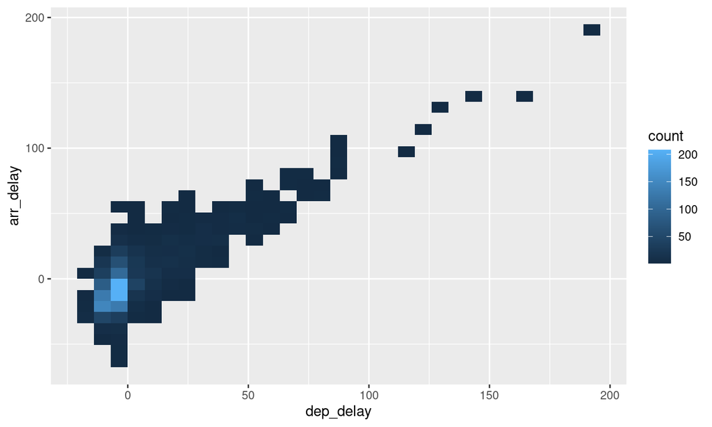

## Summary

Data visualisation

- Grammar of graphics
- ggplot2

**Next**: Descriptive statistics

- stat.desc
- dplyr::across